# Análise CBC — Rodada 2 (PIBIC / LMECC)

Segunda rodada de análises com base nas sugestões da orientadora (vic):

**Tratamentos adicionais sobre a base limpa da rodada 1:**

- **Estado civil** binarizado: com vs sem companheiro(a).
- **Faixa etária**: ≤ 40 anos vs > 40 anos *(corte clínico definido pela orientadora)*.
- **Exposição solar** ocupacional: profissões com vs sem exposição solar.
- **Subtipo do Tumor (3 categorias)**: classificação clínica padrão CBC — **Baixo risco / Alto risco / Misto** (por componentes histológicos).
- **Região anatômica**: face detalhada (nariz, malar, frontal, têmpora, pálpebra/periocular, perioral, outros) + regiões extra-faciais agrupadas.

- **Bloco A**: Estado civil × profundidade, tamanho, ulceração, margens — estratificado por sexo (8).
- **Bloco B**: Faixa etária × margens, perineural, linfovascular, ulceração, tamanho, grau, subtipo (7).
- **Bloco C**: Exposição solar × subtipo, ulceração, perineural, linfovascular, margens, tamanho, grau (7).
- **Bloco D**: Região × exposição solar, subtipo, margens, perineural, linfovascular, ulceração, grau, tamanho (8).
- **Bloco E**: Subtipo (3 cat) × região, perineural, linfovascular, grau, margens, tamanho, ulceração (7).

## 0. Setup

```python
import os, re, unicodedata, warnings
import numpy as np
import pandas as pd
import matplotlib.pyplot as plt
import matplotlib.ticker as mtick
import seaborn as sns
from scipy import stats

warnings.filterwarnings("ignore")
sns.set_theme(style="whitegrid", palette="deep")
plt.rcParams.update({"figure.dpi": 110, "savefig.dpi": 150, "savefig.bbox": "tight",
                     "axes.titleweight": "bold", "font.size": 11})

ARQUIVO = "Dados_PIBIC_LMECC_Completo(Banco de Dados) (1).csv"
FIG_DIR = "figuras_v2"
os.makedirs(FIG_DIR, exist_ok=True)

# acumulador da tabela-mestre de p-valores
RESULTADOS = []

def salvar_fig(nome):
    plt.savefig(os.path.join(FIG_DIR, nome)); print(f"[figura] {nome}")
print("Setup OK.")
```

```
Setup OK.
```

## 1. Carga do CSV

```python
brutos = pd.read_csv(ARQUIVO, sep=None, engine="python", encoding="utf-8-sig")
print("Dimensões:", brutos.shape)
brutos.head(3)
```

```
Dimensões: (419, 20)
```

|  | Código da Amostra | Data do diagnóstico | Tipo de Material Analisado | Idade ao diagnóstico | Sexo | Etnia | Estado Civil | Profissão | Subtipo do Tumor | Região Anatômica da Lesão | Tamanho da Lesão (cm) | Presença de Ulceração | infiltração | Estado de Comprometimento das Margens (Lateral) | Estado de Comprometimento das Margens (Profunda) | Reincidência? | Quantas reincidências? | Invasão Linfovascular? | Invasão Perineural? | Tratamento |
| --- | --- | --- | --- | --- | --- | --- | --- | --- | --- | --- | --- | --- | --- | --- | --- | --- | --- | --- | --- | --- |
| 0 | 77043 | 2022 | Biópsia | 70 | Masculino | Branca | Divorciado(a) | advogado | basoescamoso | dorso | 1 | Não | derme reticular | livres | livres | Não | NaN | Não | Não | NaN |
| 1 | 71171 | 2021 | Biópsia | 78 | Masculino | Negra | Casado(a) | trabalhador agrícola | misto (solido e basoescamoso) | face (nariz) | 2,3 | Sim | derme reticular média | livres | livres | Não | NaN | Não | Não | NaN |
| 2 | 55704 | 2020 | Biópsia | 81 | Feminino | Branca | Casado(a) | aposentada | misto (superficial e esclerodermiforme) | face (frontal) | 1,6 | Não | NaN | livres | livres | NaN | NaN | NaN | Não | NaN |

## 2. Limpeza herdada da rodada 1

```python
def sem_acento(s):
    if pd.isna(s): return s
    s = unicodedata.normalize("NFKD", str(s))
    return "".join(c for c in s if not unicodedata.combining(c))
def norm(s):
    if pd.isna(s): return np.nan
    s = sem_acento(str(s)).lower().strip()
    s = re.sub(r"\s+", " ", s)
    return s if s else np.nan

df = brutos.rename(columns={
    "Código da Amostra":"codigo","Data do diagnóstico":"data_dx",
    "Idade ao diagnóstico":"idade","Sexo":"sexo","Etnia":"etnia",
    "Estado Civil":"estado_civil","Profissão":"profissao",
    "Subtipo do Tumor":"subtipo_raw","Região Anatômica da Lesão":"regiao_raw",
    "Tamanho da Lesão (cm)":"tamanho_cm","Presença de Ulceração":"ulceracao",
    "infiltração":"infiltracao_raw",
    "Estado de Comprometimento das Margens (Lateral)":"margem_lat_raw",
    "Estado de Comprometimento das Margens (Profunda)":"margem_prof_raw",
    "Reincidência?":"reincidencia","Quantas reincidências?":"qtd_reincidencias",
    "Invasão Linfovascular?":"inv_linfovascular","Invasão Perineural?":"inv_perineural",
}).drop(columns=["Tipo de Material Analisado","Tratamento"], errors="ignore")

# tamanho_cm: aceita vírgula decimal do CSV
df["tamanho_cm"] = (df["tamanho_cm"].astype(str).str.replace(",", ".", regex=False)
                                                .replace({"nan": np.nan}))
df["tamanho_cm"] = pd.to_numeric(df["tamanho_cm"], errors="coerce").round(2)

df["idade"] = pd.to_numeric(df["idade"], errors="coerce")
df["sexo"] = df["sexo"].astype(str).str.strip().str.title().replace({"Nan": np.nan})
df["etnia"] = df["etnia"].astype(str).str.strip().str.title().replace({"Nan": np.nan})
df["estado_civil"] = df["estado_civil"].where(df["estado_civil"] != "Branca")

df["ulceracao"]        = df["ulceracao"].apply(norm).map({"sim":"Sim","nao":"Não"})
df["reincidencia"]     = df["reincidencia"].apply(norm).map({"sim":"Sim","nao":"Não"})
df["inv_perineural"]   = df["inv_perineural"].apply(norm).map({"sim":"Sim","nao":"Não"})
df["inv_linfovascular"]= df["inv_linfovascular"].apply(norm).map({"sim":"Sim","nao":"Não"})

def normaliza_margem(s):
    s = norm(s)
    if pd.isna(s): return np.nan
    if "comprometid" in s: return "Comprometida"
    if "livre" in s: return "Livre"
    return np.nan
df["margem_lateral"]  = df["margem_lat_raw"].apply(normaliza_margem)
df["margem_profunda"] = df["margem_prof_raw"].apply(normaliza_margem)
def comb(r):
    v=[r["margem_lateral"], r["margem_profunda"]]
    if "Comprometida" in v: return "Comprometida"
    if "Livre" in v: return "Livre"
    return np.nan
df["margem_comprometida"] = df.apply(comb, axis=1)

ORDEM_GRAU = ["1. Derme","2. Derme reticular","3. Hipoderme/subcutâneo","4. Estruturas profundas"]
def grau(s):
    s = norm(s)
    if pd.isna(s) or "nao informado" in s: return np.nan
    if any(k in s for k in ["globo ocular","muscul","musc","cartilagem","periorbit","estriad"]):
        return "4. Estruturas profundas"
    if any(k in s for k in ["hipoderme","subcut","adiposo","celular subc"]):
        return "3. Hipoderme/subcutâneo"
    if "reticular" in s or "derme profunda" in s: return "2. Derme reticular"
    if "derme" in s: return "1. Derme"
    return np.nan
df["grau_infiltracao"] = pd.Categorical(df["infiltracao_raw"].apply(grau),
                                        categories=ORDEM_GRAU, ordered=True)

# grau numérico para Kruskal etc.
df["grau_num"] = df["grau_infiltracao"].cat.codes.replace(-1, np.nan) + 1

print("Limpeza base OK. n =", len(df))
```

```
Limpeza base OK. n = 419
```

## 3. Subtipo do Tumor → 3 grupos clínicos

Classificação clínica padrão de carcinoma basocelular (literatura WHO / NCCN):

| Grupo | Componentes |
| --- | --- |
| **Baixo risco** (indolente) | nodular, sólido, superficial, adenoide, pigmentado, queratótico |
| **Alto risco** (agressivo) | esclerodermiforme, infiltrativo, micronodular, basoescamoso, metatípico |
| **Misto** | combina componentes dos dois grupos acima |

*Se a orientadora preferir outra regra, é só editar `BAIXO_RISCO`/`ALTO_RISCO` abaixo.*

```python
BAIXO_RISCO = ["nodular","solido","superficial","adenoide","pigmentado","queratotico","ceratotico"]
ALTO_RISCO  = ["esclerodermiforme","infiltrativo","micronodular","basoescamoso","metatipico","metatpico"]

def limpa_subtipo(s):
    s = norm(s)
    if pd.isna(s): return np.nan
    s = (s.replace("eesclerodermiforme","e esclerodermiforme")
          .replace("nodular a basoescamoso","nodular e basoescamoso"))
    return re.sub(r"\s+"," ", s).strip()
df["subtipo"] = df["subtipo_raw"].apply(limpa_subtipo)

def classifica_subtipo(s):
    if pd.isna(s): return np.nan
    tem_baixo = any(k in s for k in BAIXO_RISCO)
    tem_alto  = any(k in s for k in ALTO_RISCO)
    if tem_baixo and tem_alto: return "Misto"
    if tem_alto:               return "Alto risco"
    if tem_baixo:              return "Baixo risco"
    return np.nan

df["subtipo_3cat"] = df["subtipo"].apply(classifica_subtipo)
ORDEM_SUB = ["Baixo risco","Misto","Alto risco"]
df["subtipo_3cat"] = pd.Categorical(df["subtipo_3cat"], categories=ORDEM_SUB, ordered=True)
print(df["subtipo_3cat"].value_counts(dropna=False))
```

```
subtipo_3cat
Misto          272
Alto risco     147
Baixo risco      0
Name: count, dtype: int64
```

## 4. Novas variáveis derivadas (estado civil, faixa etária, exposição solar)

```python
# 4.1 estado civil binário
COM = ["Casado(a)", "União estável"]
SEM = ["Solteiro(a)", "Viúvo(a)", "Divorciado(a)"]
df["estado_civil_grupo"] = df["estado_civil"].map(
    {**{k:"Com companheiro(a)" for k in COM}, **{k:"Sem companheiro(a)" for k in SEM}})
print("Estado civil agrupado:\n", df["estado_civil_grupo"].value_counts(dropna=False))

# 4.2 faixa etária: corte 40 (orientadora)
df["faixa_etaria"] = pd.cut(df["idade"], bins=[0,40,200],
                            labels=["≤ 40 anos", "> 40 anos"], include_lowest=True)
print("\nFaixa etária (corte = 40):\n", df["faixa_etaria"].value_counts(dropna=False))

# 4.3 exposição solar ocupacional
df["profissao"] = df["profissao"].apply(norm).replace({"nao informado": np.nan,
                                                       "aposentada": "aposentado"})
COM_SOL = ["trabalhador agricola","lavrador","salineiro","pescador",
           "carpinteiro","marceneiro","eletricista","soldador","pintor",
           "trabalhador de obras","trabalhador de concreto armado",
           "trabalhador bracal","operador de maquinas","mecanico",
           "motorista","vigilante"]
SEM_SOL = ["do lar","comerciante","atendente","cozinheira","domestica",
           "domestica/copeira","vendedor","cabeleireira","lavadeira","asg",
           "seguranca","gerente de empresa",
           "professor","professora","medico","enfermeira",
           "auxiliar de enfermagem","tec enfermagem","policial",
           "funcionaria publica","funcionario publico","advogado"]
mapa_exp = {**{p:"Com exposição" for p in COM_SOL}, **{p:"Sem exposição" for p in SEM_SOL}}
df["exposicao_solar"] = df["profissao"].map(mapa_exp)
# aposentados, autônomos, desempregados -> NaN (excluídos dos testes, decisão combinada)
print("\nExposição solar:\n", df["exposicao_solar"].value_counts(dropna=False))
```

```
Estado civil agrupado:
 estado_civil_grupo
Com companheiro(a)    238
Sem companheiro(a)    174
NaN                     7
Name: count, dtype: int64

Faixa etária (corte = 40):
 faixa_etaria
> 40 anos    394
≤ 40 anos     23
NaN            2
Name: count, dtype: int64

Exposição solar:
 exposicao_solar
Com exposição    228
NaN               97
Sem exposição     94
Name: count, dtype: int64
```

## 5. Região anatômica (face detalhada + extra-facial agrupado)

Como a orientadora pediu detalhamento da face, mantemos as subregiões faciais individualmente; para as demais regiões, agrupamos por território anatômico.

```python
def classifica_regiao(s):
    s = norm(s)
    if pd.isna(s): return np.nan
    # face — detalhada
    if "face" in s or "hemiface" in s or "frontotemporal" in s or "infra - palpebral" in s or "palpebr" in s and "tronco" not in s:
        if "nariz" in s or "paranas" in s: return "Face — nariz"
        if "malar" in s: return "Face — malar"
        if "frontal" in s or "frontotemp" in s: return "Face — frontal"
        if "tempor" in s: return "Face — têmpora"
        if "palpebr" in s or "periorbit" in s or "supraorbit" in s or "orbita" in s or "globo ocular" in s:
            return "Face — pálpebra/periocular"
        if any(k in s for k in ["labio","mento","mandib","nasolab","nasogen","supralab","supercili","sobrancelha","glabela"]):
            return "Face — perioral/outros"
        return "Face — outros"
    if "couro" in s: return "Couro cabeludo"
    if "auricular" in s: return "Pavilhão/peri-auricular"
    if "cervical" in s: return "Cervical"
    if "ms" in s.split() or "membro superior" in s or "ombro" in s or "mao" in s:
        return "Membro superior"
    if "mi" in s.split() or "membro inferior" in s:
        return "Membro inferior"
    if any(k in s for k in ["dorso","dorsolateral","escapula","lombar","tronco","torax","abdominal","abdome"]):
        return "Tronco/dorso"
    return "Outros"
df["regiao_grupo"] = df["regiao_raw"].apply(classifica_regiao)
vc = df["regiao_grupo"].value_counts(dropna=False)
print(vc)
```

```
regiao_grupo
Face — nariz                  122
Pavilhão/peri-auricular        48
Face — malar                   47
Tronco/dorso                   41
Membro superior                38
Face — perioral/outros         32
Face — pálpebra/periocular     27
Face — frontal                 22
Face — têmpora                 20
Cervical                        8
Membro inferior                 5
Couro cabeludo                  5
Face — outros                   3
Outros                          1
Name: count, dtype: int64
```

## 6. Base tratada v2 — exportação

```python
df_lesao = df.copy()
df_paciente = (df_lesao.sort_values("idade")
                       .drop_duplicates(subset="codigo", keep="first")
                       .reset_index(drop=True))
print(f"Lesões: {len(df_lesao)} | Pacientes únicos: {len(df_paciente)}")
with pd.ExcelWriter("dados_tratados_v2.xlsx") as w:
    df_lesao.to_excel(w, sheet_name="por_lesao", index=False)
    df_paciente.to_excel(w, sheet_name="por_paciente", index=False)
print("[exportado] dados_tratados_v2.xlsx")
```

```
Lesões: 419 | Pacientes únicos: 285
```

```
[exportado] dados_tratados_v2.xlsx
```

## 7. Descritivos das novas variáveis

```
[figura] v2_descritivos_novos.png
```

[figure not shown]

```python
fig, axes = plt.subplots(1, 3, figsize=(14, 4))
for ax, col, tit in zip(axes,
        ["estado_civil_grupo","faixa_etaria","exposicao_solar"],
        ["Estado civil (agrupado)","Faixa etária","Exposição solar ocupacional"]):
    vc = df_lesao[col].value_counts(dropna=False)
    sns.barplot(x=vc.index.astype(str), y=vc.values, ax=ax, palette="crest")
    for i,v in enumerate(vc.values): ax.text(i, v+1, str(v), ha="center", fontweight="bold")
    ax.set(title=tit, xlabel="", ylabel="Lesões")
plt.tight_layout(); salvar_fig("v2_descritivos_novos.png"); plt.show()
```

```
[figura] v2_subtipo_regiao.png
```

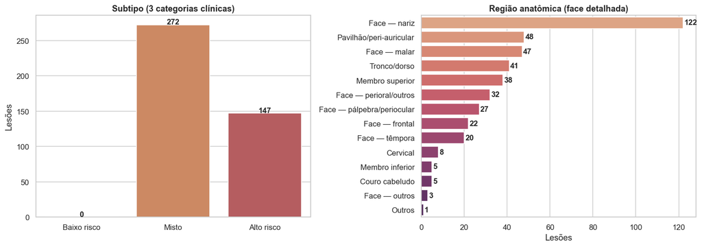

```python
fig, axes = plt.subplots(1, 2, figsize=(14, 5))
vc = df_lesao["subtipo_3cat"].value_counts(dropna=False).sort_index()
sns.barplot(x=vc.index.astype(str), y=vc.values, ax=axes[0], palette=["#55A868","#DD8452","#C44E52"])
for i,v in enumerate(vc.values): axes[0].text(i, v+1, str(v), ha="center", fontweight="bold")
axes[0].set(title="Subtipo (3 categorias clínicas)", xlabel="", ylabel="Lesões")

rg = df_lesao["regiao_grupo"].value_counts(dropna=False)
sns.barplot(y=rg.index, x=rg.values, ax=axes[1], palette="flare")
for i,v in enumerate(rg.values): axes[1].text(v+0.5, i, str(v), va="center", fontweight="bold")
axes[1].set(title="Região anatômica (face detalhada)", xlabel="Lesões", ylabel="")
plt.tight_layout(); salvar_fig("v2_subtipo_regiao.png"); plt.show()
```

## 8. Função genérica de análise

```python
def cramer_v(ct):
    chi2 = stats.chi2_contingency(ct, correction=False)[0]
    n = ct.values.sum(); r, k = ct.shape
    return float(np.sqrt(chi2/(n*(min(r,k)-1)))) if min(r,k) > 1 else np.nan

def analisa(bloco, codigo, lin, col, titulo, arquivo, data=None,
            ordem_lin=None, ordem_col=None, continua=False):
    if data is None: data = df_lesao
    sub = data.dropna(subset=[lin, col])
    n = len(sub)
    if n < 5:
        print(f"[{codigo}] {titulo}: n={n} insuficiente — pulado.")
        RESULTADOS.append({"bloco":bloco,"codigo":codigo,"cruzamento":titulo,
                           "n":n,"teste":"-","estatistica":np.nan,"p_valor":np.nan,
                           "efeito":np.nan,"significativo":""})
        return None

    print(f"\n=== [{codigo}] {titulo} ===  (n = {n})")

    if continua:  # categórica × contínua
        grupos = [sub.loc[sub[lin]==g, col].dropna() for g in sub[lin].unique()
                  if (sub[lin]==g).sum() >= 2]
        if len(grupos) < 2:
            print("Grupos insuficientes."); return None
        # estatística descritiva
        desc = sub.groupby(lin, observed=True)[col].agg(["count","mean","std","median",
                                                          lambda x: x.quantile(.25),
                                                          lambda x: x.quantile(.75)])
        desc.columns = ["n","média","desvio","mediana","q1","q3"]
        print(desc.round(2))
        if len(grupos) == 2:
            est, p = stats.mannwhitneyu(grupos[0], grupos[1], alternative="two-sided")
            n1, n2 = len(grupos[0]), len(grupos[1])
            efeito = 1 - 2*est/(n1*n2)
            teste = "Mann-Whitney"
            print(f"\n{teste}: U={est:.1f}, p={p:.4f} | r={efeito:.3f}")
        else:
            est, p = stats.kruskal(*grupos)
            efeito = est/(n - 1)   # eta² aproximado
            teste = "Kruskal-Wallis"
            print(f"\n{teste}: H={est:.3f}, p={p:.4f} | η²≈{efeito:.3f}")

        # boxplot
        fig, ax = plt.subplots(figsize=(8.5, 4.5))
        ordem = ordem_lin or list(sub[lin].dropna().unique())
        sns.boxplot(data=sub, x=lin, y=col, order=ordem, ax=ax, palette="crest", width=.55)
        sns.stripplot(data=sub, x=lin, y=col, order=ordem, ax=ax, color="black", alpha=.25, size=2)
        ax.set(title=f"{titulo}\n{teste}: p={p:.4f}", xlabel="", ylabel=col)
        plt.xticks(rotation=15, ha="right")
        salvar_fig(arquivo); plt.show()
    else:        # categórica × categórica
        ct = pd.crosstab(sub[lin], sub[col])
        if ordem_lin: ct = ct.reindex([x for x in ordem_lin if x in ct.index])
        if ordem_col: ct = ct[[x for x in ordem_col if x in ct.columns]]
        print("Frequências:\n", ct)
        pct = ct.div(ct.sum(axis=1), axis=0).mul(100).round(1)
        print("\n% por linha:\n", pct)
        chi2, p, dof, esp = stats.chi2_contingency(ct)
        v = cramer_v(ct)
        if ct.shape == (2,2):
            _, pf = stats.fisher_exact(ct)
            print(f"\nQui²={chi2:.3f}, gl={dof}, p={p:.4f} | Fisher p={pf:.4f} | V Cramer={v:.3f}")
            p_uso, teste, est_uso = pf, "Fisher (2x2)", chi2
        else:
            print(f"\nQui²={chi2:.3f}, gl={dof}, p={p:.4f} | V Cramer={v:.3f}")
            if esp.min() < 5: print(f"⚠ menor esperado={esp.min():.2f} — interpretar com cautela")
            p_uso, teste, est_uso = p, f"Qui-quadrado (gl={dof})", chi2
        efeito = v

        fig, ax = plt.subplots(figsize=(9, 4.5))
        pct.plot(kind="bar", stacked=True, ax=ax, colormap="viridis")
        ax.yaxis.set_major_formatter(mtick.PercentFormatter())
        ax.set(title=f"{titulo}\n{teste}: p={p_uso:.4f}", xlabel="", ylabel="% por linha")
        ax.legend(title=col, bbox_to_anchor=(1.02,1), loc="upper left")
        plt.xticks(rotation=20, ha="right")
        salvar_fig(arquivo); plt.show()
        est = est_uso; p = p_uso

    sig = "SIM" if (p is not None and p < 0.05) else "não"
    print(f"Significativo (α=0,05)? {sig.upper()}")
    RESULTADOS.append({"bloco":bloco,"codigo":codigo,"cruzamento":titulo,"n":n,
                       "teste": teste, "estatistica": round(float(est),3) if est==est else np.nan,
                       "p_valor": round(float(p),4) if p==p else np.nan,
                       "efeito": round(float(efeito),3) if efeito==efeito else np.nan,
                       "significativo": sig})
print("Função pronta.")
```

```
Função pronta.
```

## 9. Bloco A — Estado civil × saúde (estratificado por sexo)

Hipótese da vic: homens **sem companheira** chegam com doença mais avançada (tumores mais profundos, maiores, com mais ulceração e margens comprometidas). Replicar para mulheres.

```python
ORD_EC = ["Com companheiro(a)", "Sem companheiro(a)"]

h = df_lesao[df_lesao["sexo"]=="Masculino"].copy()
m = df_lesao[df_lesao["sexo"]=="Feminino"].copy()
print(f"Homens (lesões): {len(h)}  |  Mulheres (lesões): {len(m)}")
```

```
Homens (lesões): 252  |  Mulheres (lesões): 167
```

```
=== [A1] Homens — Estado civil × Grau de infiltração ===  (n = 236)
Frequências:
 grau_infiltracao    1. Derme  2. Derme reticular  3. Hipoderme/subcutâneo  \
estado_civil_grupo
Com companheiro(a)        14                  93                       33
Sem companheiro(a)        16                  62                       11

grau_infiltracao    4. Estruturas profundas
estado_civil_grupo
Com companheiro(a)                        5
Sem companheiro(a)                        2

% por linha:
 grau_infiltracao    1. Derme  2. Derme reticular  3. Hipoderme/subcutâneo  \
estado_civil_grupo
Com companheiro(a)       9.7                64.1                     22.8
Sem companheiro(a)      17.6                68.1                     12.1

grau_infiltracao    4. Estruturas profundas
estado_civil_grupo
Com companheiro(a)                      3.4
Sem companheiro(a)                      2.2

Qui²=6.609, gl=3, p=0.0855 | V Cramer=0.167
⚠ menor esperado=2.70 — interpretar com cautela
```

```
[figura] A1_h_civil_x_grau.png
```

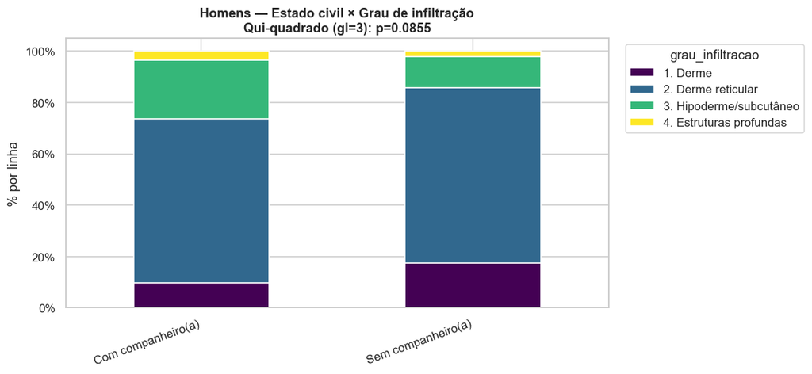

```
Significativo (α=0,05)? NÃO
```

```python
# A1 — Homens: estado civil × profundidade de infiltração
analisa("A","A1","estado_civil_grupo","grau_infiltracao",
        "Homens — Estado civil × Grau de infiltração",
        "A1_h_civil_x_grau.png", data=h, ordem_lin=ORD_EC, ordem_col=ORDEM_GRAU)
```

```
=== [A2] Homens — Estado civil × Tamanho da lesão (cm) ===  (n = 248)
                      n  média  desvio  mediana   q1   q3
estado_civil_grupo
Com companheiro(a)  153   1.66    1.32      1.2  0.9  2.0
Sem companheiro(a)   95   1.86    1.38      1.4  1.0  2.3

Mann-Whitney: U=8144.0, p=0.1099 | r=-0.121
```

```
[figura] A2_h_civil_x_tamanho.png
```

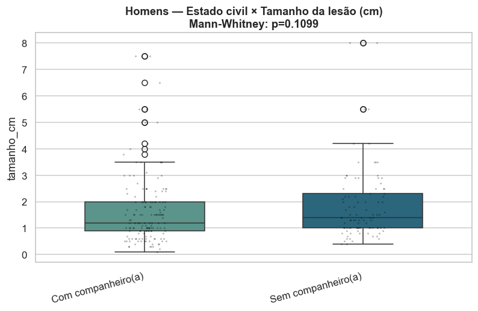

```
Significativo (α=0,05)? NÃO
```

```python
# A2 — Homens: estado civil × tamanho da lesão
analisa("A","A2","estado_civil_grupo","tamanho_cm",
        "Homens — Estado civil × Tamanho da lesão (cm)",
        "A2_h_civil_x_tamanho.png", data=h, ordem_lin=ORD_EC, continua=True)
```

```
=== [A3] Homens — Estado civil × Ulceração ===  (n = 246)
Frequências:
 ulceracao           Não  Sim
estado_civil_grupo
Com companheiro(a)   46  105
Sem companheiro(a)   27   68

% por linha:
 ulceracao            Não   Sim
estado_civil_grupo
Com companheiro(a)  30.5  69.5
Sem companheiro(a)  28.4  71.6

Qui²=0.039, gl=1, p=0.8430 | Fisher p=0.7756 | V Cramer=0.022
```

```
[figura] A3_h_civil_x_ulceracao.png
```

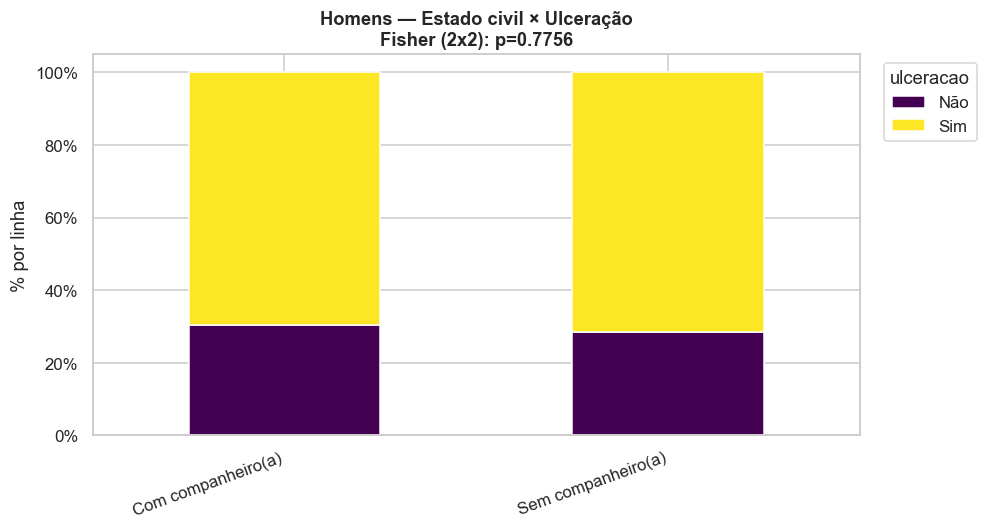

```
Significativo (α=0,05)? NÃO
```

```python
# A3 — Homens: estado civil × ulceração
analisa("A","A3","estado_civil_grupo","ulceracao",
        "Homens — Estado civil × Ulceração",
        "A3_h_civil_x_ulceracao.png", data=h, ordem_lin=ORD_EC, ordem_col=["Não","Sim"])
```

```
=== [A4] Homens — Estado civil × Margens comprometidas ===  (n = 245)
Frequências:
 margem_comprometida  Livre  Comprometida
estado_civil_grupo
Com companheiro(a)     128            23
Sem companheiro(a)      85             9

% por linha:
 margem_comprometida  Livre  Comprometida
estado_civil_grupo
Com companheiro(a)    84.8          15.2
Sem companheiro(a)    90.4           9.6

Qui²=1.173, gl=1, p=0.2788 | Fisher p=0.2442 | V Cramer=0.082
```

```
[figura] A4_h_civil_x_margens.png
```

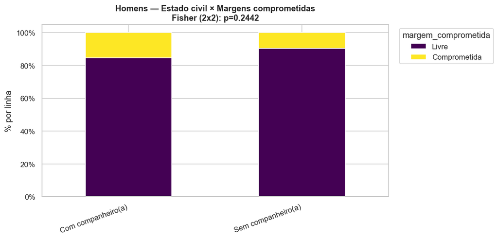

```
Significativo (α=0,05)? NÃO
```

```python
# A4 — Homens: estado civil × margens comprometidas
analisa("A","A4","estado_civil_grupo","margem_comprometida",
        "Homens — Estado civil × Margens comprometidas",
        "A4_h_civil_x_margens.png", data=h, ordem_lin=ORD_EC, ordem_col=["Livre","Comprometida"])
```

```
=== [A5] Mulheres — Estado civil × Grau de infiltração ===  (n = 147)
Frequências:
 grau_infiltracao    1. Derme  2. Derme reticular  3. Hipoderme/subcutâneo  \
estado_civil_grupo
Com companheiro(a)        14                  55                        8
Sem companheiro(a)        10                  45                        8

grau_infiltracao    4. Estruturas profundas
estado_civil_grupo
Com companheiro(a)                        1
Sem companheiro(a)                        6

% por linha:
 grau_infiltracao    1. Derme  2. Derme reticular  3. Hipoderme/subcutâneo  \
estado_civil_grupo
Com companheiro(a)      17.9                70.5                     10.3
Sem companheiro(a)      14.5                65.2                     11.6

grau_infiltracao    4. Estruturas profundas
estado_civil_grupo
Com companheiro(a)                      1.3
Sem companheiro(a)                      8.7

Qui²=4.705, gl=3, p=0.1947 | V Cramer=0.179
⚠ menor esperado=3.29 — interpretar com cautela
```

```
[figura] A5_m_civil_x_grau.png
```

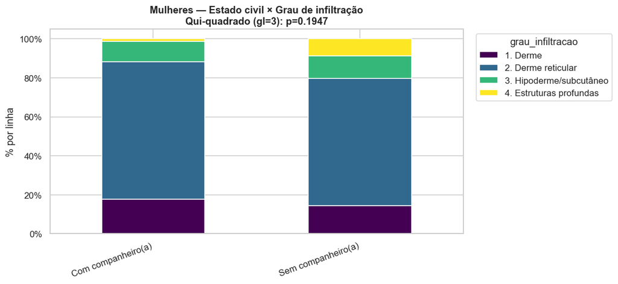

```
Significativo (α=0,05)? NÃO
```

```python
# A5 — Mulheres: estado civil × profundidade
analisa("A","A5","estado_civil_grupo","grau_infiltracao",
        "Mulheres — Estado civil × Grau de infiltração",
        "A5_m_civil_x_grau.png", data=m, ordem_lin=ORD_EC, ordem_col=ORDEM_GRAU)
```

```
=== [A6] Mulheres — Estado civil × Tamanho da lesão (cm) ===  (n = 163)
                     n  média  desvio  mediana   q1   q3
estado_civil_grupo
Com companheiro(a)  84   1.28    0.96      1.0  0.8  1.5
Sem companheiro(a)  79   1.26    0.71      1.1  0.8  1.5

Mann-Whitney: U=3126.5, p=0.5240 | r=0.058
```

```
[figura] A6_m_civil_x_tamanho.png
```

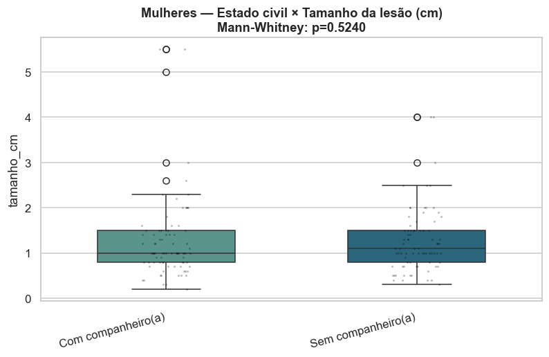

```
Significativo (α=0,05)? NÃO
```

```python
# A6 — Mulheres: estado civil × tamanho
analisa("A","A6","estado_civil_grupo","tamanho_cm",
        "Mulheres — Estado civil × Tamanho da lesão (cm)",
        "A6_m_civil_x_tamanho.png", data=m, ordem_lin=ORD_EC, continua=True)
```

```
=== [A7] Mulheres — Estado civil × Ulceração ===  (n = 162)
Frequências:
 ulceracao           Não  Sim
estado_civil_grupo
Com companheiro(a)   31   52
Sem companheiro(a)   41   38

% por linha:
 ulceracao            Não   Sim
estado_civil_grupo
Com companheiro(a)  37.3  62.7
Sem companheiro(a)  51.9  48.1

Qui²=2.906, gl=1, p=0.0883 | Fisher p=0.0818 | V Cramer=0.146
```

```
[figura] A7_m_civil_x_ulceracao.png
```

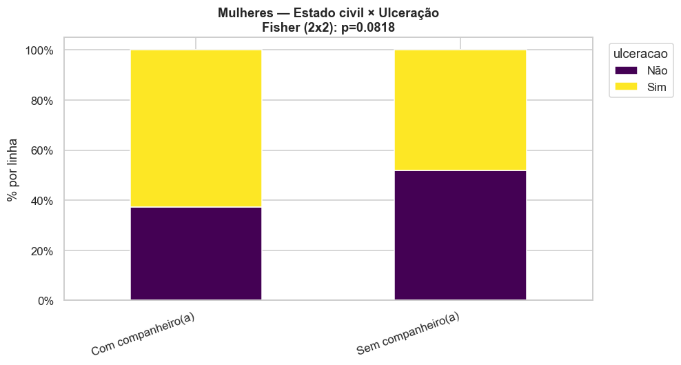

```
Significativo (α=0,05)? NÃO
```

```python
# A7 — Mulheres: estado civil × ulceração
analisa("A","A7","estado_civil_grupo","ulceracao",
        "Mulheres — Estado civil × Ulceração",
        "A7_m_civil_x_ulceracao.png", data=m, ordem_lin=ORD_EC, ordem_col=["Não","Sim"])
```

```
=== [A8] Mulheres — Estado civil × Margens comprometidas ===  (n = 164)
Frequências:
 margem_comprometida  Livre  Comprometida
estado_civil_grupo
Com companheiro(a)      74            11
Sem companheiro(a)      69            10

% por linha:
 margem_comprometida  Livre  Comprometida
estado_civil_grupo
Com companheiro(a)    87.1          12.9
Sem companheiro(a)    87.3          12.7

Qui²=0.000, gl=1, p=1.0000 | Fisher p=1.0000 | V Cramer=0.004
```

```
[figura] A8_m_civil_x_margens.png
```

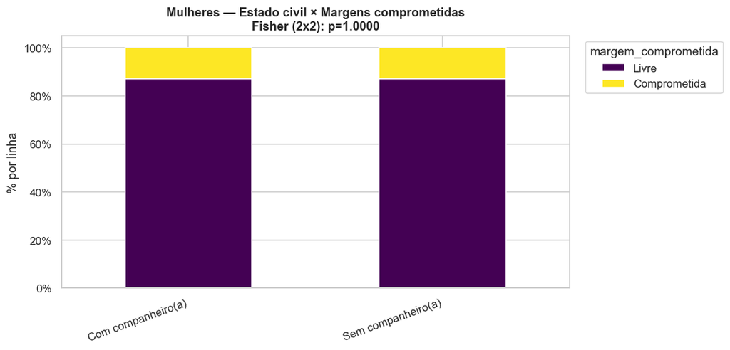

```
Significativo (α=0,05)? NÃO
```

```python
# A8 — Mulheres: estado civil × margens
analisa("A","A8","estado_civil_grupo","margem_comprometida",
        "Mulheres — Estado civil × Margens comprometidas",
        "A8_m_civil_x_margens.png", data=m, ordem_lin=ORD_EC, ordem_col=["Livre","Comprometida"])
```

## 10. Bloco B — Faixa etária (≤ 40 vs > 40) × marcadores de agressividade

*Nível lesão (419), idade ao diagnóstico.* Hipótese: CBC em jovens seria mais agressivo.

⚠ Observação: só **23 lesões em pacientes ≤ 40 anos** — interpretar com cuidado (baixo poder).

```
=== [B1] Faixa etária × Margens comprometidas ===  (n = 414)
Frequências:
 margem_comprometida  Livre  Comprometida
faixa_etaria
≤ 40 anos               22             1
> 40 anos              339            52

% por linha:
 margem_comprometida  Livre  Comprometida
faixa_etaria
≤ 40 anos             95.7           4.3
> 40 anos             86.7          13.3

Qui²=0.860, gl=1, p=0.3536 | Fisher p=0.3364 | V Cramer=0.061
```

```
[figura] B1_idade_x_margens.png
```

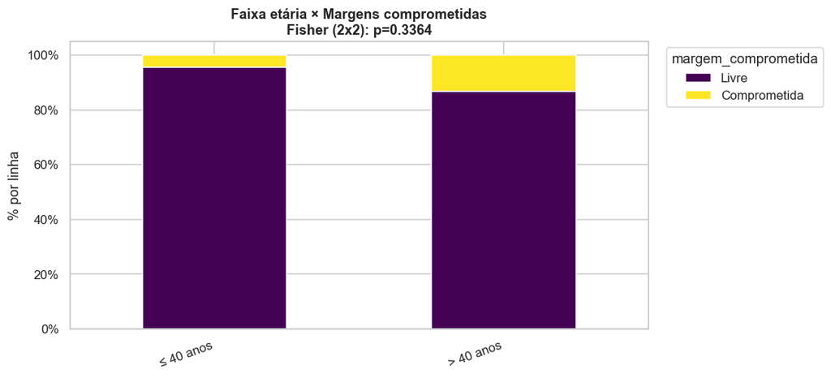

```
Significativo (α=0,05)? NÃO
```

```python
ORD_FE = ["≤ 40 anos", "> 40 anos"]
analisa("B","B1","faixa_etaria","margem_comprometida",
        "Faixa etária × Margens comprometidas",
        "B1_idade_x_margens.png", ordem_lin=ORD_FE, ordem_col=["Livre","Comprometida"])
```

```
=== [B2] Faixa etária × Invasão perineural ===  (n = 413)
Frequências:
 inv_perineural  Não  Sim
faixa_etaria
≤ 40 anos        20    3
> 40 anos       373   17

% por linha:
 inv_perineural   Não   Sim
faixa_etaria
≤ 40 anos       87.0  13.0
> 40 anos       95.6   4.4

Qui²=1.920, gl=1, p=0.1659 | Fisher p=0.0923 | V Cramer=0.093
```

```
[figura] B2_idade_x_perineural.png
```

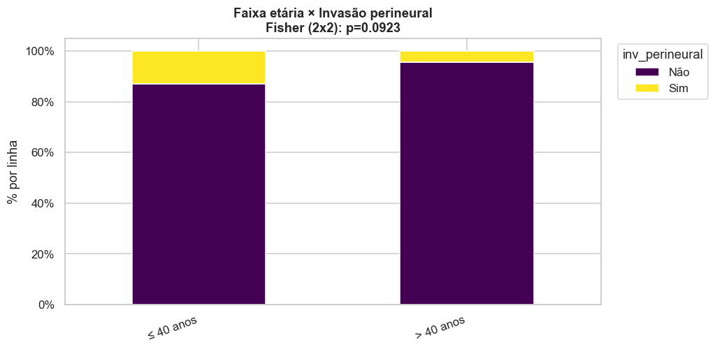

```
Significativo (α=0,05)? NÃO
```

```python
analisa("B","B2","faixa_etaria","inv_perineural",
        "Faixa etária × Invasão perineural",
        "B2_idade_x_perineural.png", ordem_lin=ORD_FE, ordem_col=["Não","Sim"])
```

```
=== [B3] Faixa etária × Invasão linfovascular ===  (n = 198)
Frequências:
 inv_linfovascular  Não
faixa_etaria
≤ 40 anos           11
> 40 anos          187

% por linha:
 inv_linfovascular    Não
faixa_etaria
≤ 40 anos          100.0
> 40 anos          100.0

Qui²=0.000, gl=0, p=1.0000 | V Cramer=nan
```

```
[figura] B3_idade_x_linfovascular.png
```

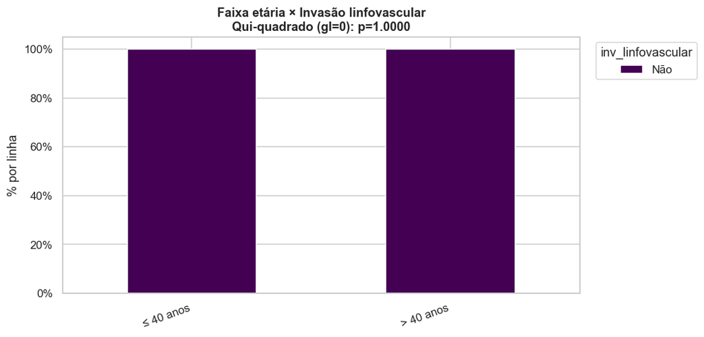

```
Significativo (α=0,05)? NÃO
```

```python
analisa("B","B3","faixa_etaria","inv_linfovascular",
        "Faixa etária × Invasão linfovascular",
        "B3_idade_x_linfovascular.png", ordem_lin=ORD_FE)
```

```
=== [B4] Faixa etária × Ulceração ===  (n = 413)
Frequências:
 ulceracao     Não  Sim
faixa_etaria
≤ 40 anos       6   16
> 40 anos     140  251

% por linha:
 ulceracao      Não   Sim
faixa_etaria
≤ 40 anos     27.3  72.7
> 40 anos     35.8  64.2

Qui²=0.343, gl=1, p=0.5583 | Fisher p=0.4971 | V Cramer=0.040
```

```
[figura] B4_idade_x_ulceracao.png
```

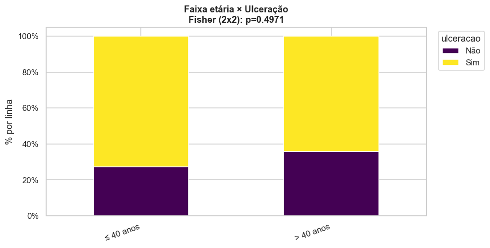

```
Significativo (α=0,05)? NÃO
```

```python
analisa("B","B4","faixa_etaria","ulceracao",
        "Faixa etária × Ulceração",
        "B4_idade_x_ulceracao.png", ordem_lin=ORD_FE, ordem_col=["Não","Sim"])
```

```
=== [B5] Faixa etária × Tamanho da lesão ===  (n = 416)
                n  média  desvio  mediana    q1   q3
faixa_etaria
≤ 40 anos      23   2.75    1.91      2.3  1.55  2.9
> 40 anos     393   1.49    1.10      1.2  0.80  1.8

Mann-Whitney: U=2084.5, p=0.0000 | r=0.539
```

```
[figura] B5_idade_x_tamanho.png
```

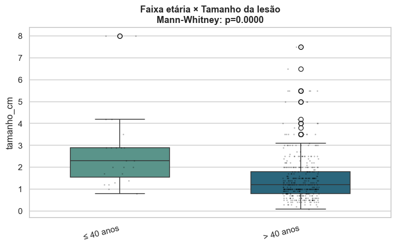

```
Significativo (α=0,05)? SIM
```

```python
analisa("B","B5","faixa_etaria","tamanho_cm",
        "Faixa etária × Tamanho da lesão",
        "B5_idade_x_tamanho.png", ordem_lin=ORD_FE, continua=True)
```

```
=== [B6] Faixa etária × Grau de infiltração ===  (n = 387)
Frequências:
 grau_infiltracao  1. Derme  2. Derme reticular  3. Hipoderme/subcutâneo  \
faixa_etaria
≤ 40 anos                1                  18                        2
> 40 anos               53                 241                       58

grau_infiltracao  4. Estruturas profundas
faixa_etaria
≤ 40 anos                               0
> 40 anos                              14

% por linha:
 grau_infiltracao  1. Derme  2. Derme reticular  3. Hipoderme/subcutâneo  \
faixa_etaria
≤ 40 anos              4.8                85.7                      9.5
> 40 anos             14.5                65.8                     15.8

grau_infiltracao  4. Estruturas profundas
faixa_etaria
≤ 40 anos                             0.0
> 40 anos                             3.8

Qui²=3.831, gl=3, p=0.2803 | V Cramer=0.099
⚠ menor esperado=0.76 — interpretar com cautela
```

```
[figura] B6_idade_x_grau.png
```

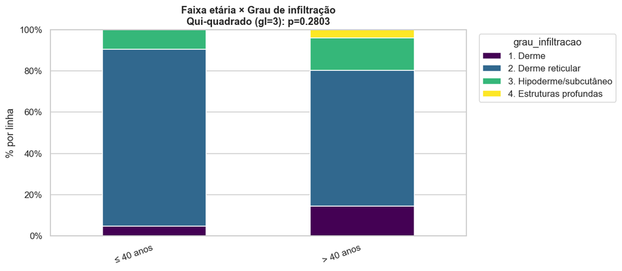

```
Significativo (α=0,05)? NÃO
```

```python
analisa("B","B6","faixa_etaria","grau_infiltracao",
        "Faixa etária × Grau de infiltração",
        "B6_idade_x_grau.png", ordem_lin=ORD_FE, ordem_col=ORDEM_GRAU)
```

```
=== [B7] Faixa etária × Subtipo (3 cat) ===  (n = 417)
Frequências:
 subtipo_3cat  Misto  Alto risco
faixa_etaria
≤ 40 anos        13          10
> 40 anos       259         135

% por linha:
 subtipo_3cat  Misto  Alto risco
faixa_etaria
≤ 40 anos      56.5        43.5
> 40 anos      65.7        34.3

Qui²=0.458, gl=1, p=0.4986 | Fisher p=0.3749 | V Cramer=0.044
```

```
[figura] B7_idade_x_subtipo.png
```

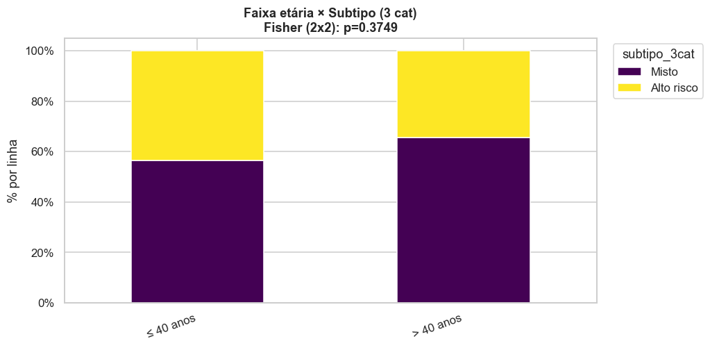

```
Significativo (α=0,05)? NÃO
```

```python
analisa("B","B7","faixa_etaria","subtipo_3cat",
        "Faixa etária × Subtipo (3 cat)",
        "B7_idade_x_subtipo.png", ordem_lin=ORD_FE, ordem_col=ORDEM_SUB)
```

## 11. Bloco C — Exposição solar ocupacional × marcadores

Profissões com vs sem exposição solar. Aposentado(a), autônomo(a), desempregado(a) e "não informado" foram **excluídos** desses testes (decisão combinada com a vic).

```
=== [C1] Exposição solar × Subtipo (3 cat) ===  (n = 322)
Frequências:
 subtipo_3cat     Misto  Alto risco
exposicao_solar
Com exposição      140          88
Sem exposição       61          33

% por linha:
 subtipo_3cat     Misto  Alto risco
exposicao_solar
Com exposição     61.4        38.6
Sem exposição     64.9        35.1

Qui²=0.213, gl=1, p=0.6445 | Fisher p=0.6134 | V Cramer=0.033
```

```
[figura] C1_exp_x_subtipo.png
```

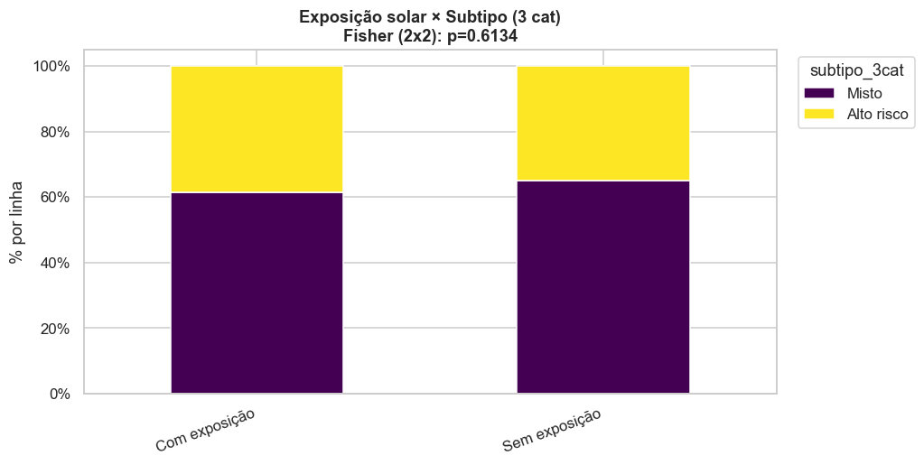

```
Significativo (α=0,05)? NÃO
```

```python
ORD_EXP = ["Com exposição", "Sem exposição"]
analisa("C","C1","exposicao_solar","subtipo_3cat",
        "Exposição solar × Subtipo (3 cat)",
        "C1_exp_x_subtipo.png", ordem_lin=ORD_EXP, ordem_col=ORDEM_SUB)
```

```
=== [C2] Exposição solar × Ulceração ===  (n = 319)
Frequências:
 ulceracao        Não  Sim
exposicao_solar
Com exposição     69  157
Sem exposição     42   51

% por linha:
 ulceracao         Não   Sim
exposicao_solar
Com exposição    30.5  69.5
Sem exposição    45.2  54.8

Qui²=5.588, gl=1, p=0.0181 | Fisher p=0.0143 | V Cramer=0.140
```

```
[figura] C2_exp_x_ulceracao.png
```

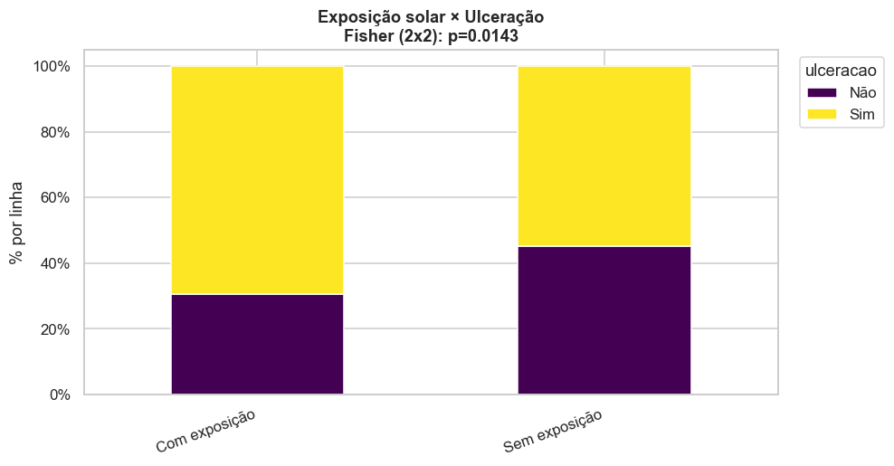

```
Significativo (α=0,05)? SIM
```

```python
analisa("C","C2","exposicao_solar","ulceracao",
        "Exposição solar × Ulceração",
        "C2_exp_x_ulceracao.png", ordem_lin=ORD_EXP, ordem_col=["Não","Sim"])
```

```
=== [C3] Exposição solar × Invasão perineural ===  (n = 318)
Frequências:
 inv_perineural   Não  Sim
exposicao_solar
Com exposição    214   10
Sem exposição     88    6

% por linha:
 inv_perineural    Não  Sim
exposicao_solar
Com exposição    95.5  4.5
Sem exposição    93.6  6.4

Qui²=0.188, gl=1, p=0.6649 | Fisher p=0.5743 | V Cramer=0.040
```

```
[figura] C3_exp_x_perineural.png
```

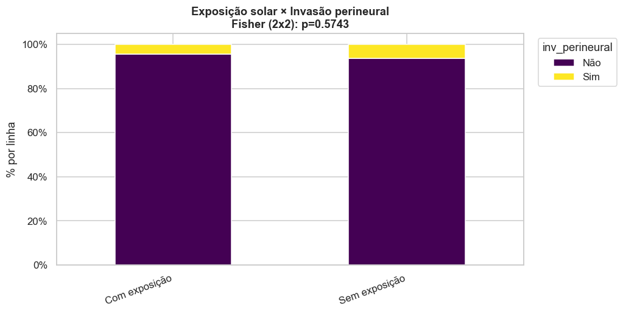

```
Significativo (α=0,05)? NÃO
```

```python
analisa("C","C3","exposicao_solar","inv_perineural",
        "Exposição solar × Invasão perineural",
        "C3_exp_x_perineural.png", ordem_lin=ORD_EXP, ordem_col=["Não","Sim"])
```

```
=== [C4] Exposição solar × Invasão linfovascular ===  (n = 156)
Frequências:
 inv_linfovascular  Não
exposicao_solar
Com exposição      113
Sem exposição       43

% por linha:
 inv_linfovascular    Não
exposicao_solar
Com exposição      100.0
Sem exposição      100.0

Qui²=0.000, gl=0, p=1.0000 | V Cramer=nan
```

```
[figura] C4_exp_x_linfovascular.png
```

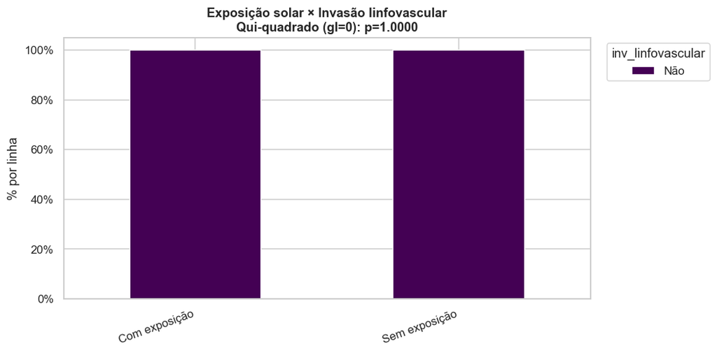

```
Significativo (α=0,05)? NÃO
```

```python
analisa("C","C4","exposicao_solar","inv_linfovascular",
        "Exposição solar × Invasão linfovascular",
        "C4_exp_x_linfovascular.png", ordem_lin=ORD_EXP)
```

```
=== [C5] Exposição solar × Margens comprometidas ===  (n = 319)
Frequências:
 margem_comprometida  Livre  Comprometida
exposicao_solar
Com exposição          192            34
Sem exposição           86             7

% por linha:
 margem_comprometida  Livre  Comprometida
exposicao_solar
Com exposição         85.0          15.0
Sem exposição         92.5           7.5

Qui²=2.687, gl=1, p=0.1012 | Fisher p=0.0961 | V Cramer=0.102
```

```
[figura] C5_exp_x_margens.png
```

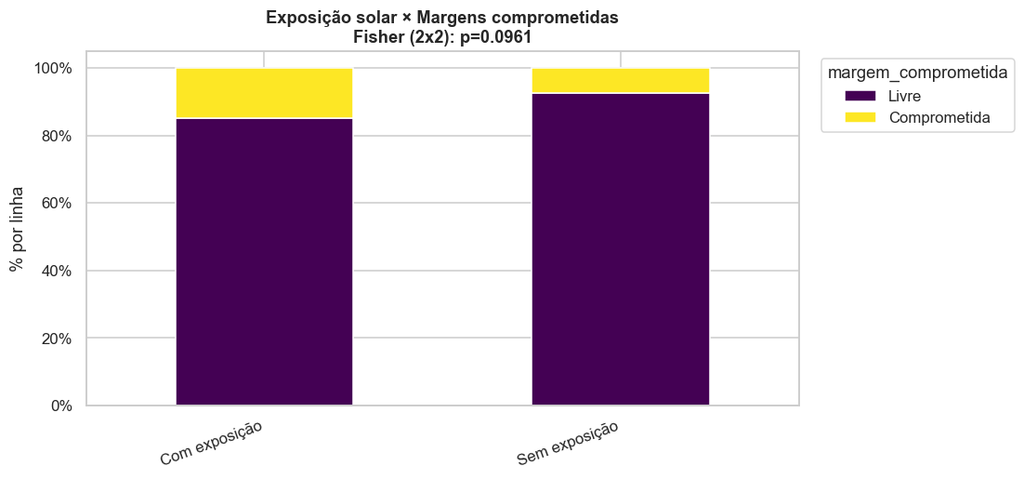

```
Significativo (α=0,05)? NÃO
```

```python
analisa("C","C5","exposicao_solar","margem_comprometida",
        "Exposição solar × Margens comprometidas",
        "C5_exp_x_margens.png", ordem_lin=ORD_EXP, ordem_col=["Livre","Comprometida"])
```

```
=== [C6] Exposição solar × Tamanho da lesão (média) ===  (n = 322)
                   n  média  desvio  mediana   q1   q3
exposicao_solar
Com exposição    228   1.55    1.18      1.2  0.9  2.0
Sem exposição     94   1.15    0.68      1.0  0.7  1.4

Mann-Whitney: U=8499.5, p=0.0034 | r=0.207
```

```
[figura] C6_exp_x_tamanho.png
```

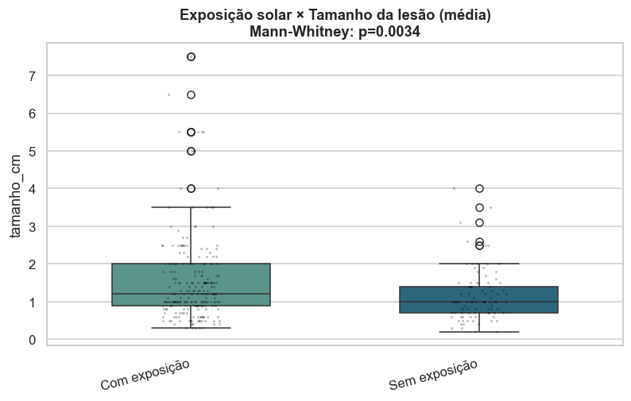

```
Significativo (α=0,05)? SIM
```

```python
analisa("C","C6","exposicao_solar","tamanho_cm",
        "Exposição solar × Tamanho da lesão (média)",
        "C6_exp_x_tamanho.png", ordem_lin=ORD_EXP, continua=True)
```

```
=== [C7] Exposição solar × Grau de infiltração ===  (n = 297)
Frequências:
 grau_infiltracao  1. Derme  2. Derme reticular  3. Hipoderme/subcutâneo  \
exposicao_solar
Com exposição           28                 139                       43
Sem exposição           14                  55                        7

grau_infiltracao  4. Estruturas profundas
exposicao_solar
Com exposição                           6
Sem exposição                           5

% por linha:
 grau_infiltracao  1. Derme  2. Derme reticular  3. Hipoderme/subcutâneo  \
exposicao_solar
Com exposição         13.0                64.4                     19.9
Sem exposição         17.3                67.9                      8.6

grau_infiltracao  4. Estruturas profundas
exposicao_solar
Com exposição                         2.8
Sem exposição                         6.2

Qui²=7.166, gl=3, p=0.0668 | V Cramer=0.155
⚠ menor esperado=3.00 — interpretar com cautela
```

```
[figura] C7_exp_x_grau.png
```

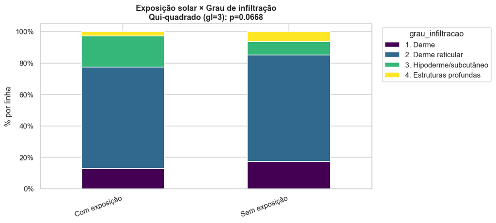

```
Significativo (α=0,05)? NÃO
```

```python
analisa("C","C7","exposicao_solar","grau_infiltracao",
        "Exposição solar × Grau de infiltração",
        "C7_exp_x_grau.png", ordem_lin=ORD_EXP, ordem_col=ORDEM_GRAU)
```

## 12. Bloco D — Região anatômica × tudo

Face detalhada (nariz, malar, frontal, têmpora, pálpebra/periocular, perioral/outros)

- regiões extra-faciais agrupadas (couro cabeludo, pavilhão/peri-auricular, cervical, membro superior, membro inferior, tronco/dorso).

```
=== [D1] Região × Exposição solar ===  (n = 322)
Frequências:
 exposicao_solar             Com exposição  Sem exposição
regiao_grupo
Cervical                                3              3
Couro cabeludo                          3              2
Face — frontal                          8              8
Face — malar                           30              7
Face — nariz                           77             27
Face — outros                           2              0
Face — perioral/outros                 18              8
Face — pálpebra/periocular             12              6
Face — têmpora                          7             10
Membro inferior                         3              1
Membro superior                        19              9
Pavilhão/peri-auricular                30              8
Tronco/dorso                           16              5

% por linha:
 exposicao_solar             Com exposição  Sem exposição
regiao_grupo
Cervical                             50.0           50.0
Couro cabeludo                       60.0           40.0
Face — frontal                       50.0           50.0
Face — malar                         81.1           18.9
Face — nariz                         74.0           26.0
Face — outros                       100.0            0.0
Face — perioral/outros               69.2           30.8
Face — pálpebra/periocular           66.7           33.3
Face — têmpora                       41.2           58.8
Membro inferior                      75.0           25.0
Membro superior                      67.9           32.1
Pavilhão/peri-auricular              78.9           21.1
Tronco/dorso                         76.2           23.8

Qui²=17.195, gl=12, p=0.1424 | V Cramer=0.231
⚠ menor esperado=0.58 — interpretar com cautela
```

```
[figura] D1_regiao_x_exposicao.png
```

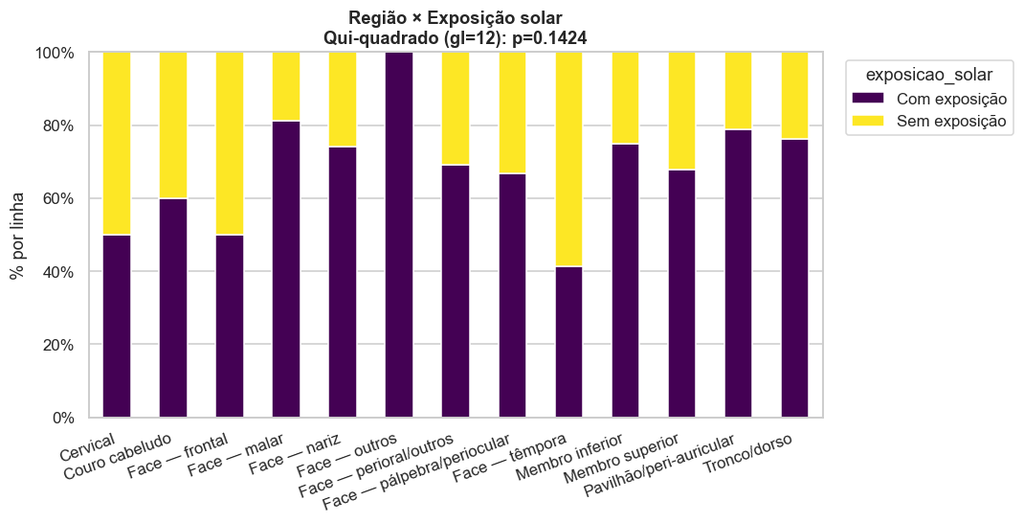

```
Significativo (α=0,05)? NÃO
```

```python
analisa("D","D1","regiao_grupo","exposicao_solar",
        "Região × Exposição solar",
        "D1_regiao_x_exposicao.png", ordem_col=["Com exposição","Sem exposição"])
```

```
=== [D2] Região × Subtipo (3 cat) ===  (n = 419)
Frequências:
 subtipo_3cat                Misto  Alto risco
regiao_grupo
Cervical                        6           2
Couro cabeludo                  2           3
Face — frontal                 17           5
Face — malar                   31          16
Face — nariz                   79          43
Face — outros                   3           0
Face — perioral/outros         22          10
Face — pálpebra/periocular     16          11
Face — têmpora                 15           5
Membro inferior                 0           5
Membro superior                25          13
Outros                          0           1
Pavilhão/peri-auricular        28          20
Tronco/dorso                   28          13

% por linha:
 subtipo_3cat                Misto  Alto risco
regiao_grupo
Cervical                     75.0        25.0
Couro cabeludo               40.0        60.0
Face — frontal               77.3        22.7
Face — malar                 66.0        34.0
Face — nariz                 64.8        35.2
Face — outros               100.0         0.0
Face — perioral/outros       68.8        31.2
Face — pálpebra/periocular   59.3        40.7
Face — têmpora               75.0        25.0
Membro inferior               0.0       100.0
Membro superior              65.8        34.2
Outros                        0.0       100.0
Pavilhão/peri-auricular      58.3        41.7
Tronco/dorso                 68.3        31.7

Qui²=18.552, gl=13, p=0.1377 | V Cramer=0.210
⚠ menor esperado=0.35 — interpretar com cautela
```

```
[figura] D2_regiao_x_subtipo.png
```

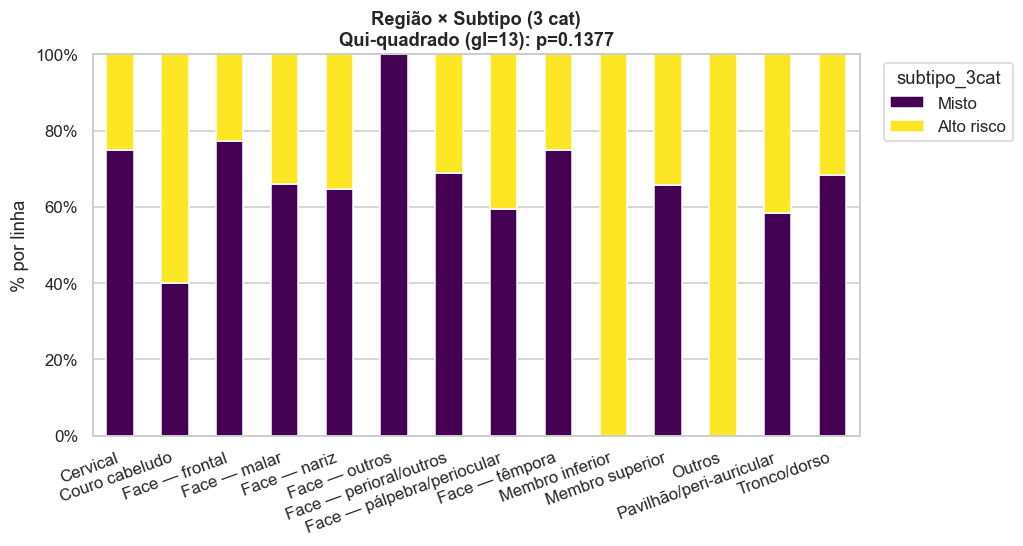

```
Significativo (α=0,05)? NÃO
```

```python
analisa("D","D2","regiao_grupo","subtipo_3cat",
        "Região × Subtipo (3 cat)",
        "D2_regiao_x_subtipo.png", ordem_col=ORDEM_SUB)
```

```
=== [D3] Região × Margens comprometidas ===  (n = 416)
Frequências:
 margem_comprometida         Livre  Comprometida
regiao_grupo
Cervical                        8             0
Couro cabeludo                  3             2
Face — frontal                 19             3
Face — malar                   43             3
Face — nariz                  101            20
Face — outros                   3             0
Face — perioral/outros         29             3
Face — pálpebra/periocular     18             8
Face — têmpora                 16             4
Membro inferior                 3             2
Membro superior                36             2
Outros                          1             0
Pavilhão/peri-auricular        43             5
Tronco/dorso                   40             1

% por linha:
 margem_comprometida         Livre  Comprometida
regiao_grupo
Cervical                    100.0           0.0
Couro cabeludo               60.0          40.0
Face — frontal               86.4          13.6
Face — malar                 93.5           6.5
Face — nariz                 83.5          16.5
Face — outros               100.0           0.0
Face — perioral/outros       90.6           9.4
Face — pálpebra/periocular   69.2          30.8
Face — têmpora               80.0          20.0
Membro inferior              60.0          40.0
Membro superior              94.7           5.3
Outros                      100.0           0.0
Pavilhão/peri-auricular      89.6          10.4
Tronco/dorso                 97.6           2.4

Qui²=26.548, gl=13, p=0.0143 | V Cramer=0.253
⚠ menor esperado=0.13 — interpretar com cautela
```

```
[figura] D3_regiao_x_margens.png
```

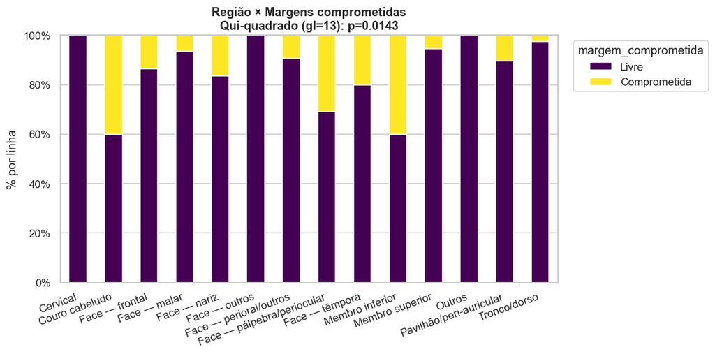

```
Significativo (α=0,05)? SIM
```

```python
analisa("D","D3","regiao_grupo","margem_comprometida",
        "Região × Margens comprometidas",
        "D3_regiao_x_margens.png", ordem_col=["Livre","Comprometida"])
```

```
=== [D4] Região × Invasão perineural ===  (n = 415)
Frequências:
 inv_perineural              Não  Sim
regiao_grupo
Cervical                      7    1
Couro cabeludo                5    0
Face — frontal               21    1
Face — malar                 45    2
Face — nariz                119    3
Face — outros                 3    0
Face — perioral/outros       31    0
Face — pálpebra/periocular   24    3
Face — têmpora               16    3
Membro inferior               5    0
Membro superior              34    3
Outros                        1    0
Pavilhão/peri-auricular      47    0
Tronco/dorso                 37    4

% por linha:
 inv_perineural                Não   Sim
regiao_grupo
Cervical                     87.5  12.5
Couro cabeludo              100.0   0.0
Face — frontal               95.5   4.5
Face — malar                 95.7   4.3
Face — nariz                 97.5   2.5
Face — outros               100.0   0.0
Face — perioral/outros      100.0   0.0
Face — pálpebra/periocular   88.9  11.1
Face — têmpora               84.2  15.8
Membro inferior             100.0   0.0
Membro superior              91.9   8.1
Outros                      100.0   0.0
Pavilhão/peri-auricular     100.0   0.0
Tronco/dorso                 90.2   9.8

Qui²=17.571, gl=13, p=0.1745 | V Cramer=0.206
⚠ menor esperado=0.05 — interpretar com cautela
```

```
[figura] D4_regiao_x_perineural.png
```

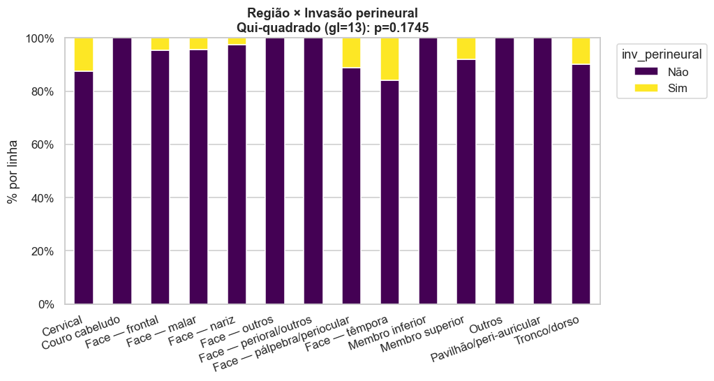

```
Significativo (α=0,05)? NÃO
```

```python
analisa("D","D4","regiao_grupo","inv_perineural",
        "Região × Invasão perineural",
        "D4_regiao_x_perineural.png", ordem_col=["Não","Sim"])
```

```
=== [D5] Região × Invasão linfovascular ===  (n = 200)
Frequências:
 inv_linfovascular           Não
regiao_grupo
Cervical                      2
Couro cabeludo                1
Face — frontal                6
Face — malar                 29
Face — nariz                 40
Face — outros                 2
Face — perioral/outros       19
Face — pálpebra/periocular   15
Face — têmpora                9
Membro superior              27
Outros                        1
Pavilhão/peri-auricular      27
Tronco/dorso                 22

% por linha:
 inv_linfovascular             Não
regiao_grupo
Cervical                    100.0
Couro cabeludo              100.0
Face — frontal              100.0
Face — malar                100.0
Face — nariz                100.0
Face — outros               100.0
Face — perioral/outros      100.0
Face — pálpebra/periocular  100.0
Face — têmpora              100.0
Membro superior             100.0
Outros                      100.0
Pavilhão/peri-auricular     100.0
Tronco/dorso                100.0

Qui²=0.000, gl=0, p=1.0000 | V Cramer=nan
⚠ menor esperado=1.00 — interpretar com cautela
```

```
[figura] D5_regiao_x_linfovascular.png
```

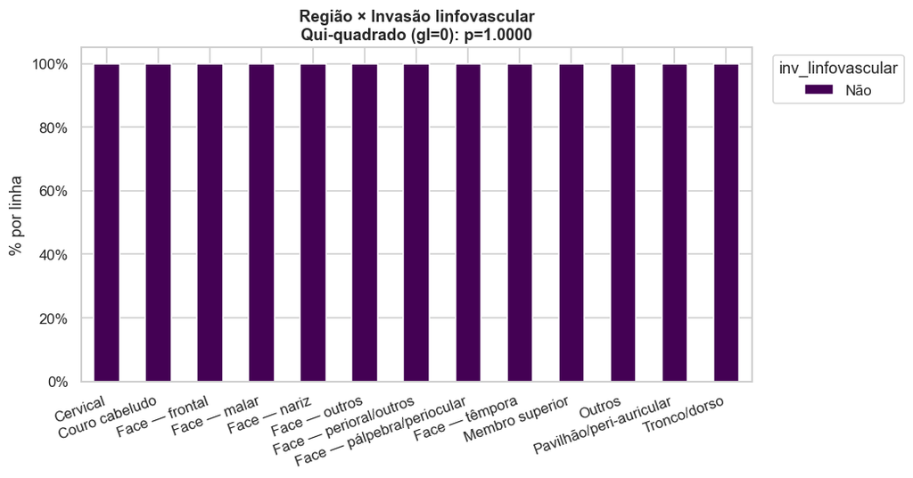

```
Significativo (α=0,05)? NÃO
```

```python
analisa("D","D5","regiao_grupo","inv_linfovascular",
        "Região × Invasão linfovascular",
        "D5_regiao_x_linfovascular.png")
```

```
=== [D6] Região × Ulceração ===  (n = 415)
Frequências:
 ulceracao                   Não  Sim
regiao_grupo
Cervical                      5    3
Couro cabeludo                2    3
Face — frontal               16    6
Face — malar                 16   31
Face — nariz                 36   85
Face — outros                 0    3
Face — perioral/outros       11   20
Face — pálpebra/periocular   13   12
Face — têmpora                7   13
Membro inferior               2    3
Membro superior               7   31
Outros                        0    1
Pavilhão/peri-auricular      13   35
Tronco/dorso                 19   22

% por linha:
 ulceracao                    Não    Sim
regiao_grupo
Cervical                    62.5   37.5
Couro cabeludo              40.0   60.0
Face — frontal              72.7   27.3
Face — malar                34.0   66.0
Face — nariz                29.8   70.2
Face — outros                0.0  100.0
Face — perioral/outros      35.5   64.5
Face — pálpebra/periocular  52.0   48.0
Face — têmpora              35.0   65.0
Membro inferior             40.0   60.0
Membro superior             18.4   81.6
Outros                       0.0  100.0
Pavilhão/peri-auricular     27.1   72.9
Tronco/dorso                46.3   53.7

Qui²=31.377, gl=13, p=0.0030 | V Cramer=0.275
⚠ menor esperado=0.35 — interpretar com cautela
```

```
[figura] D6_regiao_x_ulceracao.png
```

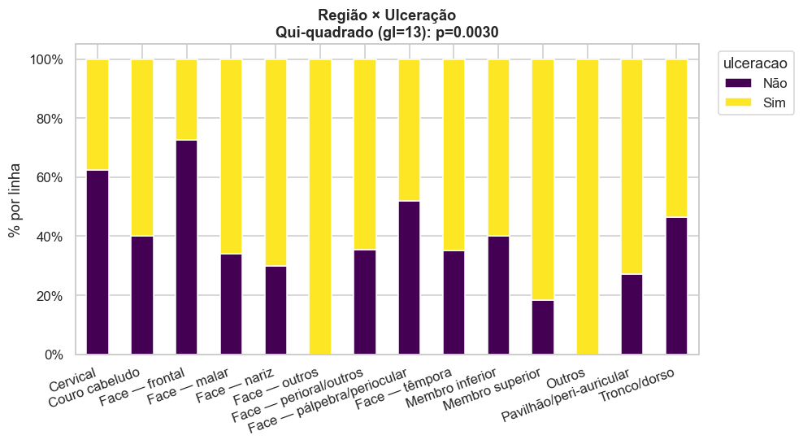

```
Significativo (α=0,05)? SIM
```

```python
analisa("D","D6","regiao_grupo","ulceracao",
        "Região × Ulceração",
        "D6_regiao_x_ulceracao.png", ordem_col=["Não","Sim"])
```

```
=== [D7] Região × Grau de infiltração ===  (n = 389)
Frequências:
 grau_infiltracao            1. Derme  2. Derme reticular  \
regiao_grupo
Cervical                           1                   3
Couro cabeludo                     3                   2
Face — frontal                     4                  14
Face — malar                       7                  31
Face — nariz                      19                  79
Face — outros                      1                   0
Face — perioral/outros             2                  18
Face — pálpebra/periocular         1                  15
Face — têmpora                     3                  10
Membro inferior                    2                   2
Membro superior                    1                  26
Outros                             0                   0
Pavilhão/peri-auricular            4                  32
Tronco/dorso                       6                  29

grau_infiltracao            3. Hipoderme/subcutâneo  4. Estruturas profundas
regiao_grupo
Cervical                                          1                        3
Couro cabeludo                                    0                        0
Face — frontal                                    0                        0
Face — malar                                      7                        1
Face — nariz                                      9                        5
Face — outros                                     2                        0
Face — perioral/outros                            6                        0
Face — pálpebra/periocular                        4                        5
Face — têmpora                                    4                        0
Membro inferior                                   1                        0
Membro superior                                   8                        0
Outros                                            1                        0
Pavilhão/peri-auricular                          12                        0
Tronco/dorso                                      5                        0

% por linha:
 grau_infiltracao            1. Derme  2. Derme reticular  \
regiao_grupo
Cervical                        12.5                37.5
```

[output cut: 18 more lines]

```
Face — frontal                                  0.0                      0.0
Face — malar                                   15.2                      2.2
Face — nariz                                    8.0                      4.5
Face — outros                                  66.7                      0.0
Face — perioral/outros                         23.1                      0.0
Face — pálpebra/periocular                     16.0                     20.0
Face — têmpora                                 23.5                      0.0
Membro inferior                                20.0                      0.0
Membro superior                                22.9                      0.0
Outros                                        100.0                      0.0
Pavilhão/peri-auricular                        25.0                      0.0
Tronco/dorso                                   12.5                      0.0

Qui²=101.044, gl=39, p=0.0000 | V Cramer=0.294
⚠ menor esperado=0.04 — interpretar com cautela
```

```
[figura] D7_regiao_x_grau.png
```

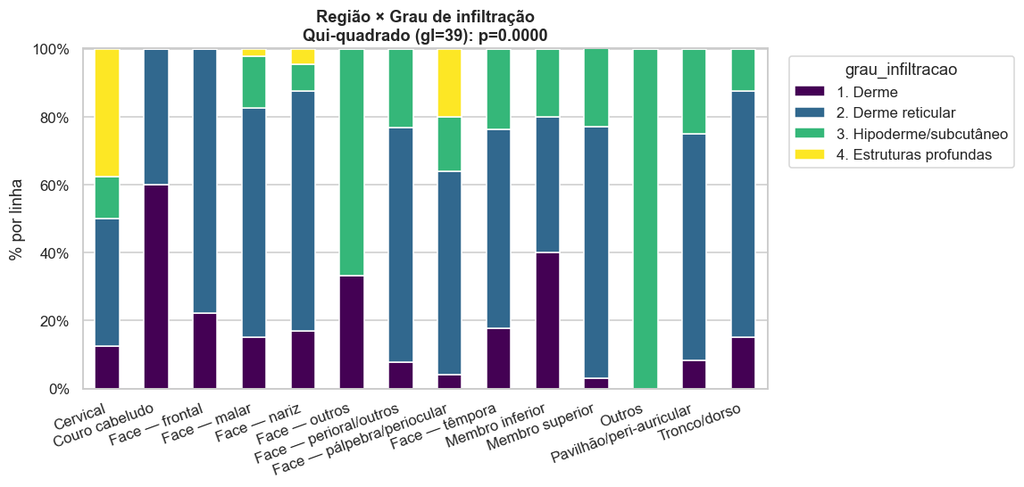

```
Significativo (α=0,05)? SIM
```

```python
analisa("D","D7","regiao_grupo","grau_infiltracao",
        "Região × Grau de infiltração",
        "D7_regiao_x_grau.png", ordem_col=ORDEM_GRAU)
```

```
=== [D8] Região × Tamanho da lesão ===  (n = 418)
```

```
                              n  média  desvio  mediana    q1    q3
regiao_grupo
Cervical                      8   1.81    0.80     1.50  1.38  2.25
Couro cabeludo                5   1.66    0.55     1.50  1.50  1.80
Face — frontal               22   1.22    0.51     1.10  0.80  1.60
Face — malar                 47   1.74    1.32     1.40  0.95  2.00
Face — nariz                122   1.17    0.86     1.00  0.60  1.50
Face — outros                 3   2.27    2.37     0.90  0.90  2.95
Face — perioral/outros       31   1.12    0.55     1.00  0.60  1.50
Face — pálpebra/periocular   27   1.23    0.87     1.00  0.60  1.50
Face — têmpora               20   1.32    1.22     1.00  0.70  1.12
Membro inferior               5   1.62    1.06     1.30  1.00  1.30
Membro superior              38   2.62    1.59     2.25  1.50  3.00
Outros                        1   0.80     NaN     0.80  0.80  0.80
Pavilhão/peri-auricular      48   1.50    0.62     1.35  1.20  2.00
Tronco/dorso                 41   2.33    1.75     2.00  1.00  2.90

Kruskal-Wallis: H=77.458, p=0.0000 | η²≈0.186
```

```
[figura] D8_regiao_x_tamanho.png
```

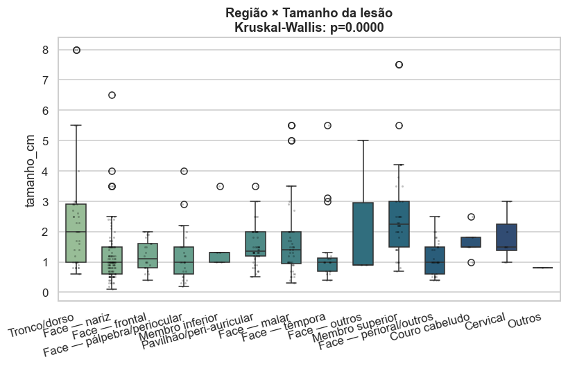

```
Significativo (α=0,05)? SIM
```

```python
analisa("D","D8","regiao_grupo","tamanho_cm",
        "Região × Tamanho da lesão",
        "D8_regiao_x_tamanho.png", continua=True)
```